# HW2 Peer Assessment

# Background

The fishing industry uses numerous measurements to describe a specific fish. Our goal is to predict the weight of a fish based on a number of these measurements and determine if any of these measurements are insignificant in determining the weigh of a product. See below for the description of these measurments.

## Data Description

The data consists of the following variables:

1. **Weight**: weight of fish in g (numerical)
2. **Species**: species name of fish (categorical)
3. **Body.Height**: height of body of fish in cm (numerical)
4. **Total.Length**: length of fish from mouth to tail in cm (numerical)
5. **Diagonal.Length**: length of diagonal of main body of fish in cm (numerical)
6. **Height**: height of head of fish in cm (numerical)
7. **Width**: width of head of fish in cm (numerical)

## Read the data

```r
# Import library you may need
library(car)
# Read the data set
fishfull = read.csv("Fish.csv",header=T, fileEncoding = 'UTF-8-BOM')
row.cnt = nrow(fishfull)
# Split the data into training and testing sets
fishtest = fishfull[(row.cnt-9):row.cnt,]
fish = fishfull[1:(row.cnt-10),]
```

*Please use fish as your data set for the following questions unless otherwise stated.*

# Question 1: Exploratory Data Analysis [10 points]

**(a) Create a box plot comparing the response variable, *Weight*, across the multiple *species*. Based on this box plot, does there appear to be a relationship between the predictor and the response?**

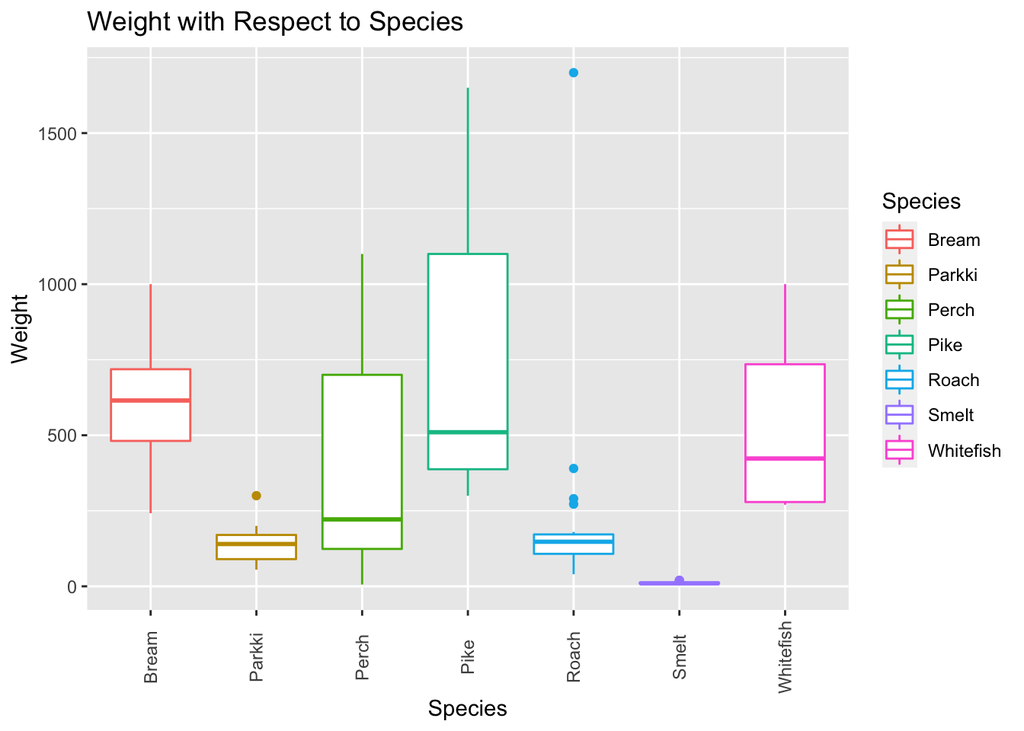

```r
library(ggplot2)
ggplot(fish, aes(x=Species, y=Weight, color=Species),
       xlab = "Species",
       ylab = "Weight") +
  geom_boxplot() +
  theme(axis.text.x  = element_text(angle=90, vjust=0.5))+
  ggtitle("Weight with Respect to Species")
```

**Answer**

- Bream - Almost normal with a slight skew towards lower weight. with not a lot of variations
- Parkki - Almost normal with a slight skew towards lower weight. with not a lot of variations. There might be some potential outliers
- Perch - the data is not normally distributed.. there is a long tail towards higher weights.
- Pike - It is similar to Perch but with a longer tail towards higher weight
- Roach - Alomst normal distribution with potentialy a lot of outliers
- Smelt - The weight is not distributed over a long range. It might also have potential outliers
- Whitefish - Similar to Perch and Pike.. with a tail towards higher weight

We might need some transformation for Perch, Pike and Whitefish.

**(b) Create plots of the response, *Weight*, against each quantitative predictor, namely** Body.Height**,** Total.Length**,** Diagonal.Length**,** Height**, and** Width**. Describe the general trend of each plot. Are there any potential outliers?**

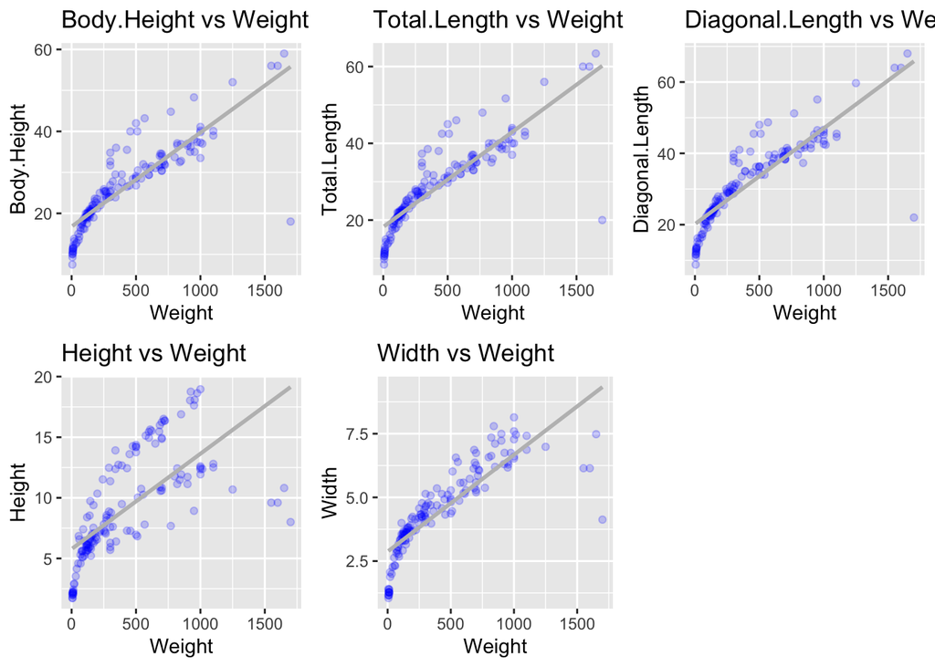

```r
library("grid")
library("ggplot2")
library("gridExtra")
par(mfrow=c(2,3))
plot(fish$Weight, fish$Body.Height)
plot(fish$Weight, fish$Total.Length)
plot(fish$Weight, fish$Diagonal.Length)
plot(fish$Weight, fish$Height)
plot(fish$Weight, fish$Width)
plot1 = ggplot(data=fish, aes(x=Weight, y=Body.Height)) + geom_point(alpha=I(0.2),color='blue') +
  xlab('Weight') + ylab('Body.Height') + ggtitle('Body.Height vs Weight') +
  geom_smooth(method= "lm",color='gray', se=FALSE)
plot2 = ggplot(data=fish, aes(x=Weight, y=Total.Length)) + geom_point(alpha=I(0.2),color='blue') +
  xlab('Weight') + ylab('Total.Length') + ggtitle('Total.Length vs Weight') +
  geom_smooth(method= "lm",color='gray', se=FALSE)
plot3 = ggplot(data=fish, aes(x=Weight, y=Diagonal.Length)) + geom_point(alpha=I(0.2),color='blue') +
  xlab('Weight') + ylab('Diagonal.Length') + ggtitle('Diagonal.Length vs Weight') +
  geom_smooth(method= "lm",color='gray', se=FALSE)
plot4 = ggplot(data=fish, aes(x=Weight, y=Height)) + geom_point(alpha=I(0.2),color='blue') +
  xlab('Weight') + ylab('Height') + ggtitle('Height vs Weight') +
  geom_smooth(method= "lm",color='gray', se=FALSE)
plot5 = ggplot(data=fish, aes(x=Weight, y=Width)) + geom_point(alpha=I(0.2),color='blue') +
  xlab('Weight') + ylab('Width') + ggtitle('Width vs Weight') +
  geom_smooth(method= "lm",color='gray', se=FALSE)
grid.arrange(plot1, plot2, plot3, plot4, plot5, ncol=3)
```

**Answer**

**(c) Display the correlations between each of the variables. Interpret the correlations in the context of the relationships of the predictors to the response and in the context of multicollinearity.**

```r
#library(corrplot)
#res <- cor(fish[ ,!(colnames(fish) == "Species")])
#corrplot(res )

cor(fish[ ,!(colnames(fish) == "Species")])
```

```
##                    Weight Body.Height Total.Length Diagonal.Length    Height
## Weight          1.0000000   0.8616894    0.8654773       0.8688250 0.6879801
## Body.Height     0.8616894   1.0000000    0.9995134       0.9919502 0.6268604
## Total.Length    0.8654773   0.9995134    1.0000000       0.9940896 0.6422261
## Diagonal.Length 0.8688250   0.9919502    0.9940896       1.0000000 0.7052116
## Height          0.6879801   0.6268604    0.6422261       0.7052116 1.0000000
## Width           0.8456717   0.8661882    0.8728030       0.8770361 0.7908491
##                     Width
## Weight          0.8456717
## Body.Height     0.8661882
## Total.Length    0.8728030
## Diagonal.Length 0.8770361
## Height          0.7908491
## Width           1.0000000
```

```r
library(GGally)
```

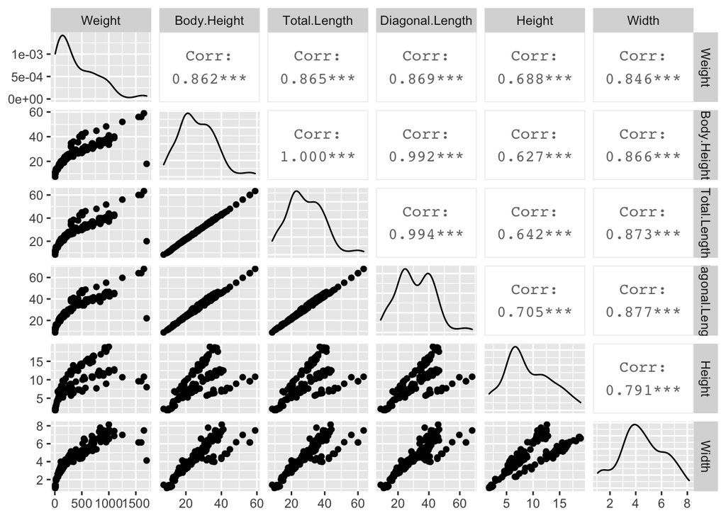

```r
ggpairs(fish[ ,!(colnames(fish) == "Species")])
```

**Answer**

- There is a moderate to high correlation between Weight and all the other predictors rnging from (0.688 - 0.869)
- Correlation between Total.Length and Body.Height is 1
- Body.Height has a
  - very high correlated to Diagonal.Length and Width
  - High correlation with Width and Weight
  - Low to moderate correlation to Height
- Total.Length
  - is highly correlated to Diagonal.Length and Width
  - high correlation to Weight and Width
  - Low to Moderate correlation to Height
- Diagonal.Length
  - has Very high correlation with Body.Height and Totla.Length
  - High correlation to Width and Weight
  - Moderate correlatin to Height
- Finally Height is also highly correlate to Width

**(d) Based on this exploratory analysis, is it reasonable to assume a multiple linear regression model for the relationship between *Weight* and the predictor variables?**

**Answer** : Based on the analysis i would still recommend a multiple linear regrssion model for the relationship between *Weight* an other predicting Variables.

# Question 2: Fitting the Multiple Linear Regression Model [11 points]

*Create the full model without transforming the response variable or predicting variables using the fish data set. Do not use fishtest*

**(a) Build a multiple linear regression model, called model1, using the response and all predictors. Display the summary table of the model.**

```r
model1 = lm(Weight ~ ., data = fish)
summary(model1)
```

```
##
## Call:
## lm(formula = Weight ~ ., data = fish)
##
## Residuals:
##     Min      1Q  Median      3Q     Max
## -211.37  -70.59  -23.50   42.42 1335.87
##
## Coefficients:
##                  Estimate Std. Error t value Pr(>|t|)
## (Intercept)       -813.90     218.34  -3.728 0.000282 ***
## SpeciesParkki       79.34     132.71   0.598 0.550918
## SpeciesPerch        10.41     206.26   0.050 0.959837
## SpeciesPike         16.76     233.06   0.072 0.942775
## SpeciesRoach       194.03     156.84   1.237 0.218173
## SpeciesSmelt       455.78     204.92   2.224 0.027775 *
## SpeciesWhitefish    28.31     164.91   0.172 0.863967
## Body.Height       -176.87      61.36  -2.882 0.004583 **
## Total.Length       266.70      77.75   3.430 0.000797 ***
## Diagonal.Length    -72.49      49.48  -1.465 0.145267
## Height              38.27      22.09   1.732 0.085448 .
## Width               29.63      40.54   0.731 0.466080
## ---
## Signif. codes:  0 '***' 0.001 '**' 0.01 '*' 0.05 '.' 0.1 ' ' 1
##
## Residual standard error: 156.1 on 137 degrees of freedom
## Multiple R-squared:  0.8419, Adjusted R-squared:  0.8292
## F-statistic:  66.3 on 11 and 137 DF,  p-value: < 2.2e-16
```

```r
#anova(model1)
```

**(b) Is the overall regression significant at an $\alpha$ level of 0.01?**

**Answer :** Final regresson p-value: < 2.2e-16. this means the that the overall regresson is significant

**(c) What is the coefficient estimate for *Body.Height*? Interpret this coefficient.**

**Answer:** - estimated coefficient for *Body.Height* is -176.87, This means that there is an inverse relationship to weight *provided all other variables are fixed*. If all the other predictors as same, we observe that for every unit of change in the Body.Height, there will be -176.87 times change in the Weight

**(d) What is the coefficient estimate for the *Species* category Parkki? Interpret this coefficient.**

**Answer :** the estimated coefficient for *Species* category Parkki is 79.34. this means that if the species is Parakki, then the intercept of the regression line will be -813.90 + 79.34 = -734.56. So the intercept for the regression line changes to -734.56.

# Question 3: Checking for Outliers and Multicollinearity [9 points]

**(a) Create a plot for the Cook’s Distances. Using a threshold Cook’s Distance of 1, identify the row numbers of any outliers.**

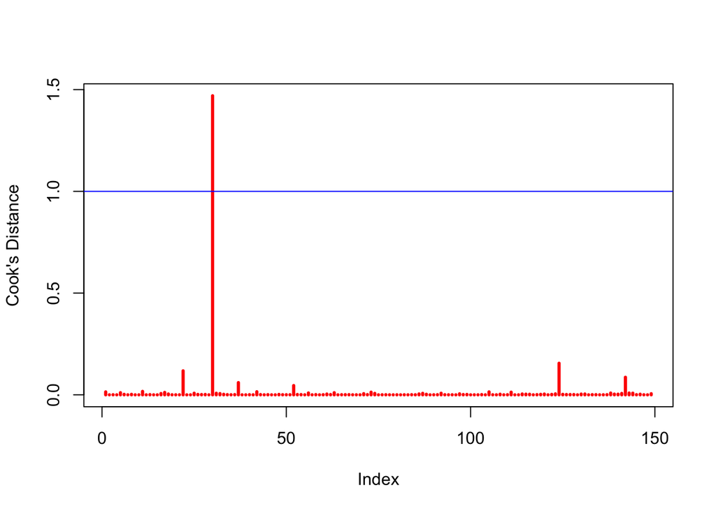

```r
library(car)
cook = cooks.distance(model1)
plot(cook,type="h",lwd=3,col="red", ylab= "Cook's Distance")
abline(1,0,col="blue")
```

```r
influential <- as.numeric(names(cook)[(cook > 1)])
influential
```

```
## [1] 30
```

**Answer :** Row number for the outlier - 30

**(b) Remove the outlier(s) from the data set and create a new model, called model2, using all predictors with *Weight* as the response. Display the summary of this model.**

```r
fish2 = fish[-30,]
model2 = lm(Weight ~ Species + Total.Length + Body.Height + Diagonal.Length + Height + Width, data = fish2)
summary(model2)
```

```
##
## Call:
## lm(formula = Weight ~ Species + Total.Length + Body.Height +
##     Diagonal.Length + Height + Width, data = fish2)
##
## Residuals:
##     Min      1Q  Median      3Q     Max
## -211.10  -50.18  -14.44   34.04  433.68
##
## Coefficients:
##                  Estimate Std. Error t value Pr(>|t|)
## (Intercept)      -969.766    131.601  -7.369 1.51e-11 ***
## SpeciesParkki     195.500     80.105   2.441 0.015951 *
## SpeciesPerch      174.241    124.404   1.401 0.163608
## SpeciesPike      -175.936    140.605  -1.251 0.212983
## SpeciesRoach      141.867     94.319   1.504 0.134871
## SpeciesSmelt      489.714    123.174   3.976 0.000113 ***
## SpeciesWhitefish  122.277     99.293   1.231 0.220270
## Total.Length       74.822     48.319   1.549 0.123825
## Body.Height       -76.321     37.437  -2.039 0.043422 *
## Diagonal.Length    34.349     30.518   1.126 0.262350
## Height             10.000     13.398   0.746 0.456692
## Width              -8.339     24.483  -0.341 0.733924
## ---
## Signif. codes:  0 '***' 0.001 '**' 0.01 '*' 0.05 '.' 0.1 ' ' 1
##
## Residual standard error: 93.84 on 136 degrees of freedom
## Multiple R-squared:  0.9385, Adjusted R-squared:  0.9335
## F-statistic: 188.6 on 11 and 136 DF,  p-value: < 2.2e-16
```

**(c) Display the VIF of each predictor for model2. Using a VIF threshold of max(10, 1/(1-$R^2$) what conclusions can you draw?**

```r
model2.r2 = summary(model2)$r.squared
model2.r2
```

```
## [1] 0.9384836
```

```r
model2.threshold = max(10, 1/(1-model2.r2))
model2.threshold
```

```
## [1] 16.25583
```

```r
model2.vif_values = car::vif(model2)
model2.vif_values
```

```
##                       GVIF Df GVIF^(1/(2*Df))
## Species         1545.55017  6        1.843983
## Total.Length    4540.47698  1       67.383062
## Body.Height     2371.15420  1       48.694499
## Diagonal.Length 2126.64985  1       46.115614
## Height            56.21375  1        7.497583
## Width             29.01683  1        5.386727
```

**Answer :** *$max(10, 1/(1-R^2$)* = 16.256. Based on this value… i think there is multicollinearity between all the predictors , with height and width having less compared to others

# Question 4: Checking Model Assumptions [9 points]

*Please use the cleaned data set, which have the outlier(s) removed, and model2 for answering the following questions.*

**(a) Create scatterplots of the standardized residuals of model2 versus each quantitative predictor. Does the linearity assumption appear to hold for all predictors?**

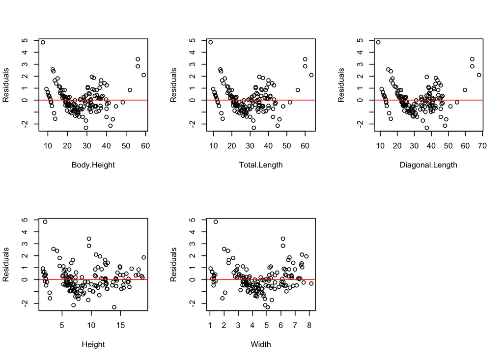

```r
library(MASS)
model2.resids= stdres(model2)
par(mfrow=c(2,3))
plot(fish2$Body.Height,model2.resids,xlab="Body.Height",ylab="Residuals")
abline(0,0,col="red")
plot(fish2$Total.Length,model2.resids,xlab="Total.Length",ylab="Residuals")
abline(0,0,col="red")
plot(fish2$Diagonal.Length,model2.resids,xlab="Diagonal.Length",ylab="Residuals")
abline(0,0,col="red")
plot(fish2$Height,model2.resids,xlab="Height",ylab="Residuals")
abline(0,0,col="red")
plot(fish2$Width,model2.resids,xlab="Width",ylab="Residuals")
abline(0,0,col="red")
```

**(b) Create a scatter plot of the standardized residuals of model2 versus the fitted values of model2. Does the constant variance assumption appear to hold? Do the errors appear uncorrelated?**

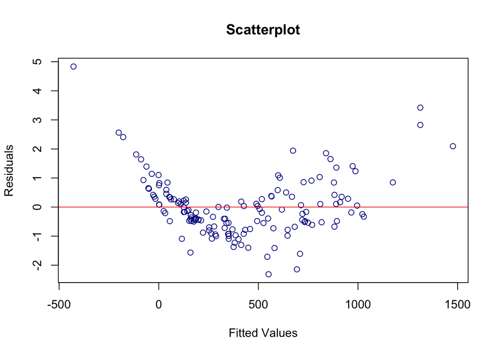

```r
model2.resids = rstandard(model2)
model2.fits = model2$fitted
plot(model2.fits, model2.resids, xlab="Fitted Values", ylab="Residuals", main="Scatterplot",
     col="darkblue")
abline(0,0,col="red")
```

**Answer :** the constant variance does not seem to hold true as the variance is not consistent.. the variance is not distributed around the 0 line. The variance is higher for < 0 and > 1000.

**(c) Create a histogram and normal QQ plot for the standardized residuals. What conclusions can you draw from these plots?**

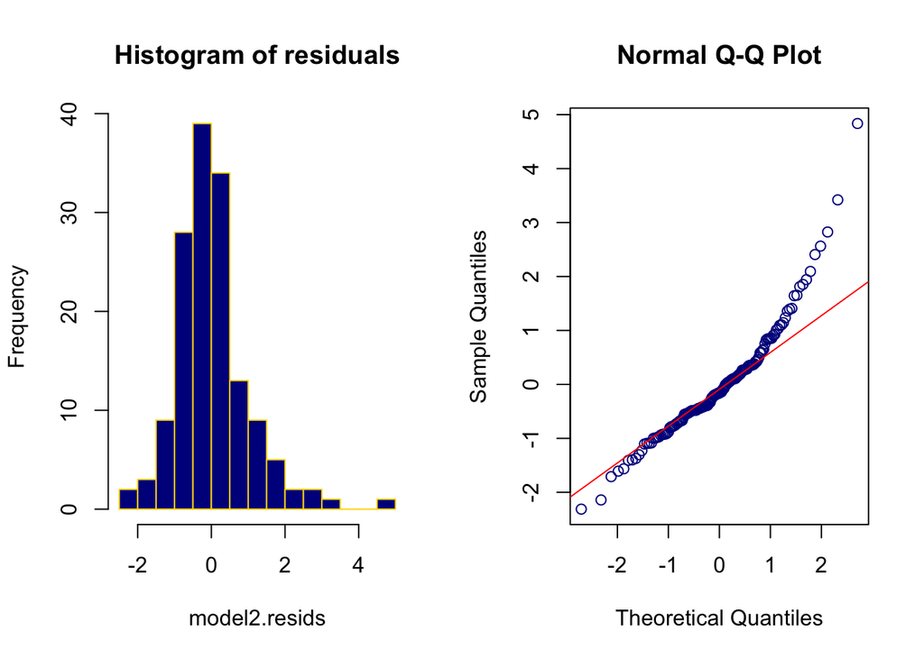

```r
par(mfrow=c(1,2))
hist(model2.resids,nclass=20, col="darkblue", border="gold",main="Histogram of residuals")
qqnorm(model2.resids,col="darkblue")
qqline(model2.resids,col="red")
```

**Answer :** The residual do not seem to be normally distributed. They have a long right tail…and looks like also have an outlier. QQ plot shos that the residuals have a right tailed distribution. There might be a need to transform the predictors and/or the response.

# Question 5 Partial F Test [6 points]

**(a) Build a third multiple linear regression model using the cleaned data set without the outlier(s), called model3, using only *Species* and *Total.Length* as predicting variables and *Weight* as the response. Display the summary table of the model3.**

```r
model3 = lm(Weight ~ Species +  Total.Length, data = fish2)
summary(model3)
```

```
##
## Call:
## lm(formula = Weight ~ Species + Total.Length, data = fish2)
##
## Residuals:
##     Min      1Q  Median      3Q     Max
## -233.83  -56.59  -10.13   34.58  418.30
##
## Coefficients:
##                  Estimate Std. Error t value Pr(>|t|)
## (Intercept)      -730.977     42.449 -17.220  < 2e-16 ***
## SpeciesParkki      63.129     38.889   1.623    0.107
## SpeciesPerch      -23.941     21.745  -1.101    0.273
## SpeciesPike      -400.964     33.350 -12.023  < 2e-16 ***
## SpeciesRoach      -19.876     30.111  -0.660    0.510
## SpeciesSmelt      256.408     39.858   6.433 1.85e-09 ***
## SpeciesWhitefish  -14.971     42.063  -0.356    0.722
## Total.Length       40.775      1.181  34.527  < 2e-16 ***
## ---
## Signif. codes:  0 '***' 0.001 '**' 0.01 '*' 0.05 '.' 0.1 ' ' 1
##
## Residual standard error: 94.86 on 140 degrees of freedom
## Multiple R-squared:  0.9353, Adjusted R-squared:  0.9321
## F-statistic: 289.1 on 7 and 140 DF,  p-value: < 2.2e-16
```

**(b) Conduct a partial F-test comparing model3 with model2. What can you conclude using an $\alpha$ level of 0.01?**

```r
anova(model3, model2)
```

|  | Res.Df | RSS | Df | Sum of Sq | F | Pr(>F) |
| --- | --- | --- | --- | --- | --- | --- |
| 1 | 140 | 1259746 | NA | NA | NA | NA |
| 2 | 136 | 1197659 | 4 | 62086.66 | 1.762561 | 0.1399744 |

# Question 6: Reduced Model Residual Analysis and Multicollinearity Test [10 points]

**(a) Conduct a multicollinearity test on model3. Comment on the multicollinearity in model3.**

```r
model3.r2 = summary(model3)$r.squared
model3.r2
```

```
## [1] 0.9352946
```

```r
model3.threshold = max(10, 1/(1-model3.r2))
model3.threshold
```

```
## [1] 15.45466
```

```r
model3.vif_values = car::vif(model3)
model3.vif_values
```

```
##                  GVIF Df GVIF^(1/(2*Df))
## Species      2.654472  6        1.084755
## Total.Length 2.654472  1        1.629255
```

```r
#barplot(model3.vif_values, main = "VIF Values", horiz = TRUE, col = "steelblue")
#abline(v = model3.threshold, lwd = 3, lty = 2)
```

**Answer :** *max(10, 1/(1-$R^2$)* = 15.45466. Based on this value… Since the vif value for all coefficients is less than 15.455, there is no significant correlation between the predictors.

**(b) Conduct residual analysis for model3 (similar to Q4). Comment on each assumption and whether they hold.**

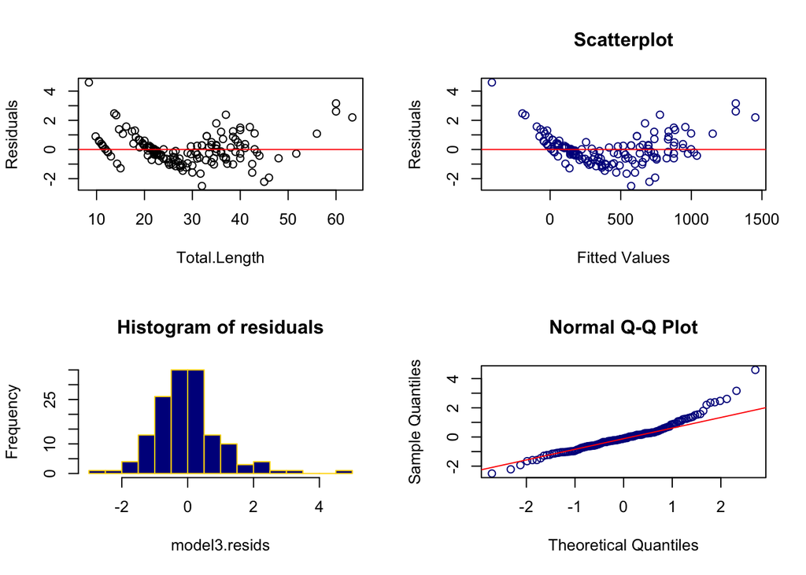

```r
library(MASS)
model3.resids= stdres(model3)
model3.fits = model3$fitted

par(mfrow=c(2,2))
plot(fish2$Total.Length,model3.resids,xlab="Total.Length",ylab="Residuals")
abline(0,0,col="red")

plot(model3.fits, model3.resids, xlab="Fitted Values", ylab="Residuals", main="Scatterplot",col="darkblue")
abline(0,0,col="red")

hist(model3.resids,nclass=20, col="darkblue", border="gold",main="Histogram of residuals")
qqnorm(model3.resids,col="darkblue")
qqline(model3.resids,col="red")
```

**Answer :** The residual plots against Total.Length does not show a random distribution around 0. Does not look like the linearity assumption holds. The Residual vs fitted value does not show a random distribution around 0. Constant Variance assumptions does not seem to hold. Residuals do not strictly follow the normality plot. The plot looks right tailed. Looks like we would beed a some data transformation.

# Question 7: Transformation [12 pts]

**(a) Use model3 to find the optimal lambda, rounded to the nearest 0.5, for a Box-Cox transformation on model3. What transformation, if any, should be applied according to the lambda value? Please ensure you use model3**

```r
b = boxCox(model3)
```

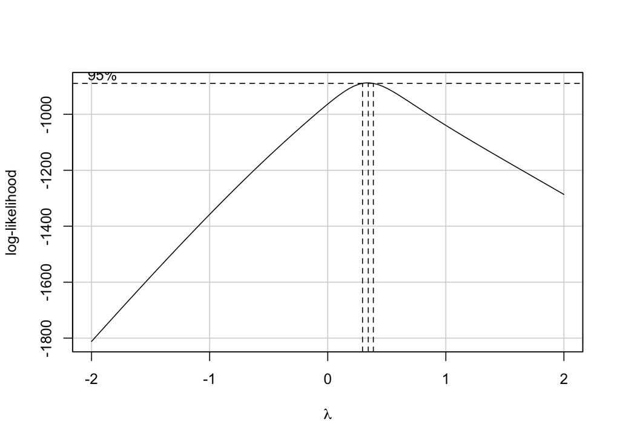

```r
lambda <- b$x # lambda values
lik <- b$y # log likelihood values for SSE
bc <- cbind(lambda, lik) # combine lambda and lik
sorted_bc <- bc[order(-lik),] # values are sorted to identify the lambda value for the maximum log likelihood for obtaining minimum SSE
head(sorted_bc, n = 10)
```

```
##          lambda       lik
##  [1,] 0.3434343 -887.5466
##  [2,] 0.3030303 -888.6628
##  [3,] 0.3838384 -889.1869
##  [4,] 0.2626263 -892.6394
##  [5,] 0.4242424 -893.3920
##  [6,] 0.2222222 -899.1985
##  [7,] 0.4646465 -899.7915
##  [8,] 0.5050505 -907.8777
##  [9,] 0.1818182 -907.9427
## [10,] 0.5454545 -917.1797
```

**Answer :** Base on the boxcox transformation … looks like $\lambda$ value of 0.5 should be used

**(b) Based on the results in (a), create model4 with the appropriate transformation. Display the summary.**

```r
model4 = lm(sqrt(Weight) ~ Species +  sqrt(Total.Length), data = fish2)
summary(model4)
```

```
##
## Call:
## lm(formula = sqrt(Weight) ~ Species + sqrt(Total.Length), data = fish2)
##
## Residuals:
##     Min      1Q  Median      3Q     Max
## -5.1790 -0.9774 -0.0938  0.8348  8.4907
##
## Coefficients:
##                    Estimate Std. Error t value Pr(>|t|)
## (Intercept)        -34.1650     1.3821 -24.719  < 2e-16 ***
## SpeciesParkki        0.3555     0.7164   0.496 0.620476
## SpeciesPerch        -1.5017     0.3991  -3.762 0.000247 ***
## SpeciesPike         -8.8115     0.5875 -14.997  < 2e-16 ***
## SpeciesRoach        -1.7616     0.5529  -3.186 0.001778 **
## SpeciesSmelt         2.2761     0.7809   2.915 0.004144 **
## SpeciesWhitefish    -0.5554     0.7653  -0.726 0.469211
## sqrt(Total.Length)  10.2147     0.2347  43.520  < 2e-16 ***
## ---
## Signif. codes:  0 '***' 0.001 '**' 0.01 '*' 0.05 '.' 0.1 ' ' 1
##
## Residual standard error: 1.726 on 140 degrees of freedom
## Multiple R-squared:  0.9668, Adjusted R-squared:  0.9651
## F-statistic: 581.6 on 7 and 140 DF,  p-value: < 2.2e-16
```

**(c) Perform Residual Analysis on model4. Comment on each assumption. Was the transformation successful/unsuccessful?**

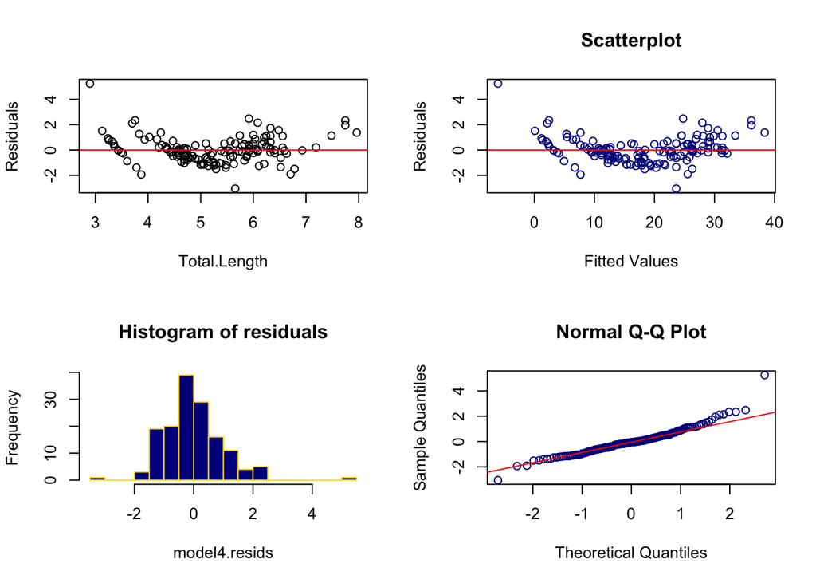

```r
model4.resids= stdres(model4)
model4.fits = model4$fitted

par(mfrow=c(2,2))
plot(sqrt(fish2$Total.Length),model4.resids,xlab="Total.Length",ylab="Residuals")
abline(0,0,col="red")

plot(model4.fits, model4.resids, xlab="Fitted Values", ylab="Residuals", main="Scatterplot",col="darkblue")
abline(0,0,col="red")

hist(model4.resids,nclass=20, col="darkblue", border="gold",main="Histogram of residuals")
qqnorm(model4.resids,col="darkblue")
qqline(model4.resids,col="red")
```

**Answer :** Looks like the transformation has improved the linearity, normality and constant variance .. the Residuals look to have tails on both the sides and some outliers.

# Question 8: Model Comparison [3pts]

**(a) Using each model summary, compare and discuss the R-squared and Adjusted R-squared of model2, model3, and model4.**

**Answer :**

| Model | $R^2$ | $Adj-R^2$ |
| --- | --- | --- |
| Model2 | 0.9384836 | 0.933508 |
| Model3 | 0.9352946 | 0.9320593 |
| Model4 | 0.9667547 | 0.9650924 |

Model 2 & Model 3 have cery similar $R^2$ values but Model 4 has a higher $R^2$ as well as $Adj - R^2$. Model 4 does a better job of explaining the variance in the model.

# Question 9: Estimation and Prediction [10 points]

**(a) Estimate Weight for the last 10 rows of data (fishtest) using both model3 and model4. Compare and discuss the mean squared prediction error (MSPE) of both models.**

```r
fishtest
```

|  | Weight | Species | Body.Height | Total.Length | Diagonal.Length | Height | Width |
| --- | --- | --- | --- | --- | --- | --- | --- |
| 150 | 650.0 | Perch | 36.5 | 39.0 | 41.4 | 11.1366 | 6.0030 |
| 151 | 450.0 | Bream | 27.6 | 30.0 | 35.1 | 14.0049 | 4.8438 |
| 152 | 273.0 | Parkki | 23.0 | 25.0 | 28.0 | 11.0880 | 4.1440 |
| 153 | 78.0 | Perch | 16.8 | 18.7 | 19.4 | 5.1992 | 3.1234 |
| 154 | 145.0 | Perch | 22.0 | 24.0 | 25.5 | 6.3750 | 3.8250 |
| 155 | 40.0 | Perch | 13.8 | 15.0 | 16.0 | 3.8240 | 2.4320 |
| 156 | 200.0 | Pike | 30.0 | 32.3 | 34.8 | 5.5680 | 3.3756 |
| 157 | 540.0 | Pike | 40.1 | 43.0 | 45.8 | 7.7860 | 5.1296 |
| 158 | 150.0 | Parkki | 18.4 | 20.0 | 22.4 | 8.8928 | 3.2928 |
| 159 | 9.8 | Smelt | 11.4 | 12.0 | 13.2 | 2.2044 | 1.1484 |

```r
model3.pred = predict(model3, fishtest, interval = 'prediction')
model4.pred = predict(model4, fishtest, interval = 'prediction')
model3.pred
```

```
##             fit        lwr       upr
## 150  835.320989  644.30713 1026.3348
## 151  492.283575  301.85813  682.7090
## 152  351.535704  153.48729  549.5841
## 153    7.581312 -183.04331  198.2059
## 154  223.690686   34.10391  413.2775
## 155 -143.287496 -335.10709   48.5321
## 156  185.102637  -11.41631  381.6216
## 157  621.398920  427.53262  815.2652
## 158  147.658936  -50.02673  345.3446
## 159   14.734838 -179.88560  209.3553
```

```r
'^'(model4.pred, 2)
```

```
##           fit          lwr       upr
## 150 790.96465 6.075195e+02 998.57745
## 151 474.50870 3.355834e+02 637.43647
## 152 298.04755 1.865415e+02 435.56061
## 153  72.33930 2.534478e+01 143.42800
## 154 206.63837 1.193886e+02 317.67117
## 155  15.16854 1.536397e-01  54.72142
## 156 227.31047 1.326127e+02 347.37056
## 157 576.27791 4.194367e+02 757.97936
## 158 140.94633 6.848162e+01 239.28383
## 159  12.22118 2.029875e-03  49.51677
```

```r
model3.pred1 <-model3.pred[,1]
model4.pred1 <-'^'(model4.pred[,1],2)


model3.mspe = mean((model3.pred1 - fishtest$Weight)^2)
model4.mspe = mean((model4.pred1 - fishtest$Weight)^2)

model3.mspe
```

```
## [1] 9392.25
```

```r
model4.mspe
```

```
## [1] 2769.68
```

**Answer :** MSPE for Model3 is 9392.2496917 and for Mode l4 = 2769.6799582. Model 4 is able to predict the weight closer to the actual weight compare to Model 3.

**(b) Suppose you have found a Perch fish with a Body.Height of 28 cm, and a Total.Length of 32 cm. Using model4, predict the weight on this fish with a 90% prediction interval. Provide an interpretation of the prediction interval.**